# Replication Notes for Nagano (2015): Adult Heritage Language Speakers in the United States

Replication notebook

2026-04-21

# 1 Purpose

This RMarkdown file documents a replication of Nagano (2015), “Demographics of Adult Heritage Language Speakers in the United States: Differences by Region and Language and Their Implications,” using the reduced IPUMS extracts in `data/`.

The goal is a faithful reconstruction of the paper’s descriptive analyses:

- Race/ethnicity and Hispanic-origin summaries for 1980, 1990, 2000, and 2010.
- Broad estimates of people who speak a language other than English at home.
- Narrow estimates of adult heritage language (HL) speakers.
- State-level counts and proportions of adult HL speakers.
- Language-level counts, shares, and growth rates.
- State-specific language profiles for California, Texas, New York, Florida, and New Mexico.
- Gini indexes for the geographic concentration of adult HL speakers by language.

The data files are reduced samples of the original research data, so exact numerical matches to the published article are not expected. The central ordering of states/languages and the substantive patterns should be close.

# 2 Paper-Based Analytic Definition

Nagano (2015) defines adult HL speakers operationally using the variables available in the U.S. Census/ACS via IPUMS. The target respondents are people who:

1. are age 18 or older;
2. speak a language other than English at home;
3. report at least some English speaking ability, excluding those who “do not speak English”; and
4. if foreign-born, immigrated to the United States at age 18 or younger.

The last item is approximate because the public-use files provide year of immigration rather than exact age at arrival.

# 3 Load Packages and Data

```r
library(dplyr)
library(forcats)
library(ggplot2)
library(haven)
library(knitr)
library(readr)
library(scales)
library(stringr)
library(tidyr)
```

```r
data_dir <- "data"
data_files <- list.files(data_dir, pattern = "[.]sav$", full.names = TRUE)
data_files <- data_files[order(readr::parse_number(basename(data_files)))]
basename(data_files)
```

```
## [1] "DATA_DOWNLOADED_FROM_IPUMS_SAMPLE1980.sav"
## [2] "DATA_DOWNLOADED_FROM_IPUMS_SAMPLE1990.sav"
## [3] "DATA_DOWNLOADED_FROM_IPUMS_SAMPLE2000.sav"
## [4] "DATA_DOWNLOADED_FROM_IPUMS_SAMPLE2010.sav"
```

Only the variables needed for this replication are loaded. This keeps the analysis closer to the published methods while reducing memory use.

```r
vars_needed <- c(
  "YEAR", "STATEFIP", "CONSPUMA", "PERWT", "AGE", "BPL", "YRIMMIG",
  "LANGUAGE", "SPEAKENG", "RACESING", "HISPAN"
)

read_ipums_file <- function(path) {
  message("Reading ", basename(path))
  haven::read_sav(path, col_select = any_of(vars_needed)) |>
    mutate(source_file = basename(path))
}

raw <- data_files |>
  lapply(read_ipums_file) |>
  bind_rows()

glimpse(raw)
```

```
## Rows: 4,037,895
## Columns: 12
## $ YEAR        <dbl+lbl> 1980, 1980, 1980, 1980, 1980, 1980, 1980, 1980, 1980, …
## $ STATEFIP    <dbl+lbl> 2, 2, 2, 2, 2, 2, 2, 2, 2, 2, 2, 2, 2, 2, 2, 2, 2, 2, …
## $ CONSPUMA    <dbl> 540, 540, 540, 540, 540, 540, 540, 540, 540, 540, 540, 540…
## $ PERWT       <dbl> 200, 200, 200, 200, 200, 200, 200, 200, 200, 200, 200, 200…
## $ AGE         <dbl+lbl> 58, 59, 42, 24, 24, 37, 29, 35, 35,  6,  3, 27, 25,  5…
## $ HISPAN      <dbl+lbl> 0, 0, 0, 0, 0, 0, 0, 0, 0, 0, 0, 0, 0, 0, 0, 0, 0, 0, …
## $ BPL         <dbl+lbl> 17, 17, 46, 51, 24, 54, 42, 29, 29, 29, 22, 28, 28,  2…
## $ YRIMMIG     <dbl+lbl> 0, 0, 0, 0, 0, 0, 0, 0, 0, 0, 0, 0, 0, 0, 0, 0, 0, 0, …
## $ LANGUAGE    <dbl+lbl>  1,  1,  1,  1,  1,  1,  1,  1,  1,  1,  1,  1,  1,  1…
## $ SPEAKENG    <dbl+lbl> 3, 3, 3, 3, 3, 3, 3, 3, 3, 3, 3, 3, 3, 3, 3, 0, 3, 3, …
## $ RACESING    <dbl+lbl> 1, 1, 1, 1, 1, 1, 1, 1, 1, 1, 1, 2, 2, 2, 2, 2, 1, 1, …
## $ source_file <chr> "DATA_DOWNLOADED_FROM_IPUMS_SAMPLE1980.sav", "DATA_DOWNLOA…
```

# 4 Labels and Helper Functions

```r
label_lookup <- function(x) {
  labs <- attr(x, "labels")
  tibble(
    value = as.numeric(labs),
    label = names(labs)
  )
}

state_lookup <- label_lookup(raw$STATEFIP) |>
  rename(state_code = value, state = label)

race_lookup <- label_lookup(raw$RACESING) |>
  rename(race_code = value, race = label)

hispan_lookup <- label_lookup(raw$HISPAN) |>
  rename(hispan_code = value, hispanic_origin = label)

language_lookup <- label_lookup(raw$LANGUAGE) |>
  rename(language_code = value, language = label) |>
  mutate(
    language = str_replace_all(language, "/", " "),
    language = str_replace_all(language, "East Southeast", "East/Southeast")
  )

pct_change <- function(new, old) {
  ifelse(is.na(old) | old == 0, NA_real_, (new - old) / old)
}

average_decade_increase <- function(x, years = c(1980, 1990, 2000, 2010)) {
  x <- x[match(years, names(x))]
  mean(c(
    pct_change(x[2], x[1]),
    pct_change(x[3], x[2]),
    pct_change(x[4], x[3])
  ), na.rm = TRUE)
}

average_decade_from_columns <- function(df) {
  decade_cols <- c("1980", "1990", "2000", "2010")
  apply(as.data.frame(df[decade_cols]), 1, average_decade_increase)
}

weighted_n <- function(x) sum(x, na.rm = TRUE)

fmt_n <- function(x) comma(round(x, 0), accuracy = 1)
fmt_pct <- function(x) percent(x, accuracy = 0.01)

gini <- function(x) {
  x <- as.numeric(x)
  x <- x[is.finite(x)]
  if (length(x) == 0 || sum(x) == 0) return(NA_real_)
  x <- sort(x)
  n <- length(x)
  (2 * sum(seq_along(x) * x) / (n * sum(x))) - ((n + 1) / n)
}
```

```r
analytic <- raw |>
  mutate(
    state_code = as.numeric(STATEFIP),
    language_code = as.numeric(LANGUAGE),
    race_code = as.numeric(RACESING),
    hispan_code = as.numeric(HISPAN),
    perwt = as.numeric(PERWT),
    age = as.numeric(AGE),
    bpl = as.numeric(BPL),
    yrimmig = as.numeric(YRIMMIG),
    speakeng = as.numeric(SPEAKENG),
    year = as.numeric(YEAR),
    state_conspuma = paste(state_code, as.numeric(CONSPUMA), sep = "_"),
    us_born = bpl <= 120,
    age_at_immigration = if_else(!us_born & yrimmig > 0, year - yrimmig, NA_real_),
    speaks_lote_home = !language_code %in% c(0, 1, 95, 99),
    speaks_some_english = speakeng %in% c(2, 4, 5, 6),
    arrived_by_18_or_us_born = us_born | (!is.na(age_at_immigration) & age_at_immigration <= 18),
    adult_hl = age >= 18 & speaks_lote_home & speaks_some_english & arrived_by_18_or_us_born
  ) |>
  left_join(state_lookup, by = "state_code") |>
  left_join(language_lookup, by = "language_code") |>
  left_join(race_lookup, by = "race_code") |>
  left_join(hispan_lookup, by = "hispan_code")

analytic |>
  count(year, adult_hl)
```

```
## # A tibble: 8 × 3
##    year adult_hl       n
##   <dbl> <lgl>      <int>
## 1  1980 FALSE    1067698
## 2  1980 TRUE       67617
## 3  1990 FALSE     929737
## 4  1990 TRUE       69784
## 5  2000 FALSE     901856
## 6  2000 TRUE       85116
## 7  2010 FALSE     836804
## 8  2010 TRUE       79283
```

# 5 Table 3: Race/Ethnicity

The paper’s Table 3 reports weighted population totals by `RACESING` for 1980, 1990, 2000, and 2010, plus the average decade-to-decade increase.

```r
race_table <- analytic |>
  filter(!is.na(race)) |>
  group_by(race, year) |>
  summarise(n = weighted_n(perwt), .groups = "drop") |>
  pivot_wider(names_from = year, values_from = n, values_fill = 0) |>
  mutate(`Average Increase` = average_decade_from_columns(pick(everything()))) |>
  arrange(desc(`2010`))

total_population <- analytic |>
  group_by(year) |>
  summarise(n = weighted_n(perwt), .groups = "drop") |>
  pivot_wider(names_from = year, values_from = n) |>
  mutate(race = "Total Population",
         `Average Increase` = average_decade_from_columns(pick(everything()))) |>
  select(race, everything())

bind_rows(total_population, race_table) |>
  mutate(across(c(`1980`, `1990`, `2000`, `2010`), fmt_n),
         `Average Increase` = fmt_pct(`Average Increase`)) |>
  kable(caption = "Replication of Table 3: Race/Ethnicity Data")
```

Replication of Table 3: Race/Ethnicity Data

| race | 1980 | 1990 | 2000 | 2010 | Average Increase |
| --- | --- | --- | --- | --- | --- |
| Total Population | 227,063,000 | 247,985,100 | 281,499,955 | 309,255,493 | 10.86% |
| White | 194,825,200 | 208,734,638 | 230,951,254 | 248,540,910 | 8.47% |
| Black | 26,703,800 | 29,852,800 | 36,119,247 | 41,537,065 | 15.93% |
| Asian and/or Pacific Islander | 3,759,600 | 7,109,500 | 11,347,745 | 15,888,290 | 62.91% |
| American Indian/Alaska Native | 1,553,000 | 2,023,412 | 2,658,293 | 2,744,972 | 21.64% |
| Other race, non-Hispanic | 221,400 | 264,750 | 423,416 | 544,256 | 36.02% |

# 6 Table 4: Hispanic or Latino Origin

The paper’s Table 4 reports weighted population totals by `HISPAN`.

```r
hispan_table <- analytic |>
  filter(!is.na(hispanic_origin), hispanic_origin != "Not Reported") |>
  group_by(hispanic_origin, year) |>
  summarise(n = weighted_n(perwt), .groups = "drop") |>
  pivot_wider(names_from = year, values_from = n, values_fill = 0) |>
  mutate(`Average Increase` = average_decade_from_columns(pick(everything()))) |>
  arrange(match(hispanic_origin, c("Not Hispanic", "Mexican", "Puerto Rican", "Cuban", "Other")))

bind_rows(
  total_population |> rename(hispanic_origin = race),
  hispan_table
) |>
  mutate(across(c(`1980`, `1990`, `2000`, `2010`), fmt_n),
         `Average Increase` = fmt_pct(`Average Increase`)) |>
  kable(caption = "Replication of Table 4: Hispanic or Latino Origin Data")
```

Replication of Table 4: Hispanic or Latino Origin Data

| hispanic_origin | 1980 | 1990 | 2000 | 2010 | Average Increase |
| --- | --- | --- | --- | --- | --- |
| Total Population | 227,063,000 | 247,985,100 | 281,499,955 | 309,255,493 | 10.86% |
| Not Hispanic | 212,335,200 | 226,230,262 | 246,263,769 | 258,321,542 | 6.77% |
| Mexican | 8,757,600 | 13,336,975 | 20,883,315 | 32,985,790 | 55.61% |
| Puerto Rican | 2,036,600 | 2,617,338 | 3,401,239 | 4,767,920 | 32.88% |
| Cuban | 807,800 | 1,037,450 | 1,268,078 | 1,887,654 | 33.17% |
| Other | 3,125,800 | 4,763,075 | 9,683,554 | 11,292,587 | 57.43% |

# 7 Figures 1 and 2: State Counts in 2010

Figure 1 uses a broad home-language definition: all respondents who speak a language other than English at home. Figure 2 applies the narrower adult-HL definition used in the main analysis.

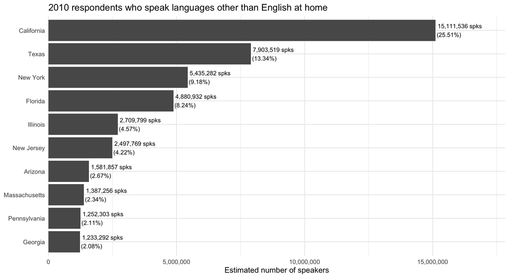

```r
fig1_data <- analytic |>
  filter(year == 2010, speaks_lote_home) |>
  group_by(state) |>
  summarise(n = weighted_n(perwt), .groups = "drop") |>
  mutate(prop = n / sum(n)) |>
  slice_max(n, n = 10) |>
  arrange(n) |>
  mutate(label = paste0(fmt_n(n), " spks\n(", fmt_pct(prop), ")"),
         state = fct_reorder(state, n))

ggplot(fig1_data, aes(x = state, y = n)) +
  geom_col(fill = "gray35") +
  geom_text(aes(label = label), hjust = -0.05, size = 3.3) +
  coord_flip(clip = "off") +
  scale_y_continuous(labels = comma, expand = expansion(mult = c(0, 0.18))) +
  labs(
    title = "2010 respondents who speak languages other than English at home",
    x = NULL,
    y = "Estimated number of speakers"
  ) +
  theme_minimal(base_size = 12)
```

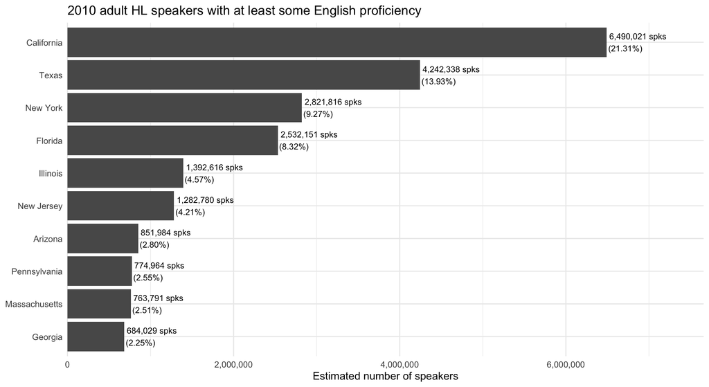

```r
fig2_data <- analytic |>
  filter(year == 2010, adult_hl) |>
  group_by(state) |>
  summarise(n = weighted_n(perwt), .groups = "drop") |>
  mutate(prop = n / sum(n)) |>
  slice_max(n, n = 10) |>
  arrange(n) |>
  mutate(label = paste0(fmt_n(n), " spks\n(", fmt_pct(prop), ")"),
         state = fct_reorder(state, n))

ggplot(fig2_data, aes(x = state, y = n)) +
  geom_col(fill = "gray35") +
  geom_text(aes(label = label), hjust = -0.05, size = 3.3) +
  coord_flip(clip = "off") +
  scale_y_continuous(labels = comma, expand = expansion(mult = c(0, 0.18))) +
  labs(
    title = "2010 adult HL speakers with at least some English proficiency",
    x = NULL,
    y = "Estimated number of speakers"
  ) +
  theme_minimal(base_size = 12)
```

# 8 Table 5: Adult HL Speakers by State

```r
state_hl_counts <- analytic |>
  filter(adult_hl, !is.na(state), state != "State not identified") |>
  group_by(state, year) |>
  summarise(n = weighted_n(perwt), .groups = "drop") |>
  pivot_wider(names_from = year, values_from = n, values_fill = 0) |>
  mutate(`Average Increase Rate per Decade` = average_decade_from_columns(pick(everything()))) |>
  arrange(desc(`2010`))

state_hl_total <- analytic |>
  filter(adult_hl) |>
  group_by(year) |>
  summarise(n = weighted_n(perwt), .groups = "drop") |>
  pivot_wider(names_from = year, values_from = n) |>
  mutate(state = "Total",
         `Average Increase Rate per Decade` = average_decade_from_columns(pick(everything()))) |>
  select(state, everything())

bind_rows(state_hl_counts, state_hl_total) |>
  mutate(across(c(`1980`, `1990`, `2000`, `2010`), fmt_n),
         `Average Increase Rate per Decade` = fmt_pct(`Average Increase Rate per Decade`)) |>
  kable(caption = "Replication of Table 5: Adult HL Speakers by State")
```

Replication of Table 5: Adult HL Speakers by State

| state | 1980 | 1990 | 2000 | 2010 | Average Increase Rate per Decade |
| --- | --- | --- | --- | --- | --- |
| California | 2,626,400 | 4,467,212 | 5,821,999 | 6,490,021 | 37.30% |
| Texas | 1,678,400 | 2,360,212 | 3,335,879 | 4,242,338 | 36.38% |
| New York | 1,785,600 | 2,168,800 | 2,764,922 | 2,821,816 | 17.00% |
| Florida | 573,000 | 1,006,838 | 1,721,497 | 2,532,151 | 64.59% |
| Illinois | 672,200 | 824,475 | 1,177,943 | 1,392,616 | 27.92% |
| New Jersey | 584,200 | 752,688 | 1,142,357 | 1,282,780 | 30.97% |
| Arizona | 300,600 | 437,838 | 711,144 | 851,984 | 42.63% |
| Pennsylvania | 499,400 | 510,525 | 644,571 | 774,964 | 16.24% |
| Massachusetts | 430,000 | 505,225 | 646,099 | 763,791 | 21.20% |
| Georgia | 88,600 | 186,888 | 443,308 | 684,029 | 100.81% |
| Virginia | 143,800 | 248,325 | 442,766 | 638,548 | 65.07% |
| Washington | 170,800 | 223,238 | 447,807 | 569,824 | 52.85% |
| Maryland | 158,400 | 234,962 | 374,379 | 489,514 | 46.14% |
| North Carolina | 85,800 | 154,988 | 385,132 | 487,927 | 85.27% |
| New Mexico | 318,400 | 375,188 | 413,006 | 458,138 | 12.95% |
| Michigan | 350,200 | 353,838 | 487,605 | 449,784 | 10.36% |
| Colorado | 194,800 | 214,012 | 386,874 | 441,294 | 34.90% |
| Connecticut | 248,800 | 271,125 | 345,705 | 438,195 | 21.08% |
| Ohio | 306,600 | 333,438 | 417,790 | 429,654 | 12.30% |
| Nevada | 43,200 | 92,100 | 230,179 | 334,935 | 102.88% |
| Minnesota | 165,000 | 168,438 | 233,421 | 288,229 | 21.38% |
| Oregon | 86,000 | 98,762 | 219,998 | 280,700 | 55.06% |
| Indiana | 137,400 | 164,675 | 263,952 | 279,792 | 28.71% |
| Louisiana | 324,800 | 321,338 | 281,859 | 243,580 | -8.98% |
| Wisconsin | 165,800 | 162,325 | 214,043 | 236,576 | 13.43% |
| Tennessee | 61,200 | 93,600 | 174,230 | 218,282 | 54.79% |
| Missouri | 93,800 | 116,925 | 164,948 | 212,210 | 31.46% |
| Utah | 64,000 | 83,900 | 140,944 | 211,355 | 49.68% |
| Oklahoma | 84,600 | 98,538 | 156,937 | 184,057 | 31.01% |
| South Carolina | 43,400 | 76,912 | 140,915 | 172,244 | 60.89% |
| Hawaii | 154,800 | 175,725 | 173,016 | 164,401 | 2.33% |
| Kansas | 77,400 | 89,525 | 113,298 | 153,279 | 25.84% |
| Alabama | 38,600 | 78,212 | 107,300 | 136,663 | 55.73% |
| Kentucky | 42,400 | 56,175 | 104,487 | 125,210 | 46.11% |
| Iowa | 73,800 | 68,262 | 101,588 | 107,922 | 15.85% |
| Rhode Island | 93,000 | 97,075 | 100,717 | 102,154 | 3.19% |
| Arkansas | 26,000 | 36,588 | 70,143 | 93,507 | 55.25% |
| Idaho | 33,400 | 37,000 | 59,790 | 81,145 | 36.03% |
| Alaska | 32,400 | 37,738 | 61,761 | 74,472 | 33.57% |
| Mississippi | 27,600 | 38,625 | 62,646 | 70,507 | 38.23% |
| Nebraska | 49,200 | 50,462 | 72,457 | 70,401 | 14.44% |
| District of Columbia | 27,800 | 47,225 | 75,598 | 62,308 | 37.46% |
| Delaware | 20,200 | 34,525 | 42,911 | 61,964 | 46.54% |
| New Hampshire | 66,600 | 64,412 | 70,914 | 54,372 | -5.51% |
| Maine | 78,600 | 84,050 | 61,775 | 53,163 | -11.17% |
| South Dakota | 40,200 | 37,438 | 33,058 | 37,725 | -1.48% |
| Montana | 25,400 | 26,125 | 27,989 | 26,950 | 2.09% |
| Wyoming | 20,200 | 15,450 | 24,633 | 23,006 | 9.77% |
| North Dakota | 64,800 | 36,000 | 36,871 | 16,810 | -32.14% |
| Vermont | 20,400 | 21,012 | 26,090 | 16,650 | -3.01% |
| West Virginia | 25,400 | 32,788 | 36,043 | 15,301 | -6.18% |
| Total | 13,523,400 | 18,271,738 | 25,795,292 | 30,449,237 | 31.44% |

# 9 Table 6: Proportion of Adult HL Speakers in Each State

```r
state_pop <- analytic |>
  filter(!is.na(state), state != "State not identified") |>
  group_by(state, year) |>
  summarise(pop = weighted_n(perwt), .groups = "drop")

state_hl_long <- analytic |>
  filter(adult_hl, !is.na(state), state != "State not identified") |>
  group_by(state, year) |>
  summarise(hl = weighted_n(perwt), .groups = "drop")

state_prop <- state_pop |>
  left_join(state_hl_long, by = c("state", "year")) |>
  mutate(hl = replace_na(hl, 0), prop = hl / pop) |>
  select(state, year, prop) |>
  pivot_wider(names_from = year, values_from = prop) |>
  mutate(`Difference Between 2010 and 1980` = `2010` - `1980`) |>
  arrange(state)

state_prop |>
  mutate(across(c(`1980`, `1990`, `2000`, `2010`, `Difference Between 2010 and 1980`), fmt_pct)) |>
  kable(caption = "Replication of Table 6: Adult HL Speakers as a Share of State Population")
```

Replication of Table 6: Adult HL Speakers as a Share of State Population

| state | 1980 | 1990 | 2000 | 2010 | Difference Between 2010 and 1980 |
| --- | --- | --- | --- | --- | --- |
| Alabama | 0.98% | 1.94% | 2.40% | 2.89% | 1.91% |
| Alaska | 7.86% | 6.95% | 9.90% | 10.47% | 2.61% |
| Arizona | 11.03% | 11.72% | 13.60% | 13.23% | 2.20% |
| Arkansas | 1.14% | 1.59% | 2.65% | 3.24% | 2.10% |
| California | 11.06% | 15.04% | 17.20% | 17.38% | 6.32% |
| Colorado | 6.76% | 6.58% | 8.91% | 8.69% | 1.94% |
| Connecticut | 8.01% | 8.26% | 10.32% | 12.50% | 4.50% |
| Delaware | 3.36% | 5.15% | 5.50% | 6.95% | 3.59% |
| District of Columbia | 4.36% | 8.03% | 12.57% | 9.96% | 5.60% |
| Florida | 5.83% | 7.72% | 10.68% | 13.52% | 7.69% |
| Georgia | 1.61% | 2.86% | 5.35% | 7.02% | 5.41% |
| Hawaii | 15.94% | 15.59% | 13.89% | 11.91% | -4.03% |
| Idaho | 3.60% | 3.73% | 4.65% | 5.14% | 1.54% |
| Illinois | 5.91% | 7.27% | 9.47% | 10.83% | 4.92% |
| Indiana | 2.49% | 2.96% | 4.30% | 4.31% | 1.82% |
| Iowa | 2.53% | 2.46% | 3.45% | 3.47% | 0.95% |
| Kansas | 3.30% | 3.65% | 4.18% | 5.29% | 2.00% |
| Kentucky | 1.16% | 1.55% | 2.56% | 2.86% | 1.70% |
| Louisiana | 7.71% | 7.62% | 6.42% | 5.28% | -2.43% |
| Maine | 6.85% | 6.79% | 4.87% | 4.11% | -2.74% |
| Maryland | 3.77% | 4.92% | 7.13% | 8.51% | 4.74% |
| Massachusetts | 7.53% | 8.36% | 10.11% | 11.39% | 3.86% |
| Michigan | 3.79% | 3.78% | 4.89% | 4.61% | 0.82% |
| Minnesota | 4.07% | 3.87% | 4.75% | 5.40% | 1.34% |
| Mississippi | 1.09% | 1.51% | 2.22% | 2.36% | 1.27% |
| Missouri | 1.92% | 2.29% | 2.93% | 3.54% | 1.62% |
| Montana | 3.25% | 3.28% | 3.00% | 2.70% | -0.55% |
| Nebraska | 3.11% | 3.15% | 4.36% | 3.83% | 0.73% |
| Nevada | 5.36% | 7.62% | 11.32% | 12.40% | 7.04% |
| New Hampshire | 7.37% | 5.89% | 5.80% | 4.15% | -3.22% |
| New Jersey | 7.94% | 9.79% | 13.61% | 14.53% | 6.59% |
| New Mexico | 24.39% | 24.41% | 22.94% | 22.15% | -2.25% |
| New York | 10.14% | 12.06% | 14.60% | 14.51% | 4.38% |
| North Carolina | 1.45% | 2.35% | 4.82% | 5.13% | 3.67% |
| North Dakota | 9.93% | 5.57% | 5.54% | 2.59% | -7.34% |
| Ohio | 2.85% | 3.09% | 3.71% | 3.73% | 0.88% |
| Oklahoma | 2.80% | 3.14% | 4.64% | 4.85% | 2.06% |
| Oregon | 3.24% | 3.55% | 6.33% | 7.28% | 4.04% |
| Pennsylvania | 4.18% | 4.33% | 5.26% | 6.03% | 1.85% |
| Rhode Island | 9.81% | 9.62% | 9.89% | 9.75% | -0.06% |
| South Carolina | 1.39% | 2.19% | 3.46% | 3.69% | 2.29% |
| South Dakota | 5.76% | 5.33% | 4.31% | 4.60% | -1.16% |
| Tennessee | 1.33% | 1.93% | 3.07% | 3.49% | 2.16% |
| Texas | 11.71% | 14.05% | 16.14% | 17.01% | 5.30% |
| Utah | 4.28% | 4.99% | 6.37% | 7.60% | 3.32% |
| Vermont | 4.01% | 3.83% | 4.28% | 2.66% | -1.34% |
| Virginia | 2.65% | 4.07% | 6.22% | 7.93% | 5.28% |
| Washington | 4.12% | 4.65% | 7.55% | 8.46% | 4.34% |
| West Virginia | 1.31% | 1.82% | 1.98% | 0.81% | -0.50% |
| Wisconsin | 3.50% | 3.33% | 4.03% | 4.15% | 0.65% |
| Wyoming | 4.27% | 3.37% | 4.91% | 4.14% | -0.13% |

# 10 Table 7: Adult HL Speakers by Language

```r
language_counts <- analytic |>
  filter(adult_hl, !is.na(language), !language %in% c("No language", "Other or not reported", "Not reported, blank")) |>
  group_by(language, year) |>
  summarise(n = weighted_n(perwt), .groups = "drop") |>
  pivot_wider(names_from = year, values_from = n, values_fill = 0) |>
  mutate(
    `Percentage in 2010` = `2010` / sum(`2010`, na.rm = TRUE),
    `Average Increase Rate per Decade` = average_decade_from_columns(pick(everything()))
  ) |>
  arrange(desc(`2010`))

language_total <- analytic |>
  filter(adult_hl) |>
  group_by(year) |>
  summarise(n = weighted_n(perwt), .groups = "drop") |>
  pivot_wider(names_from = year, values_from = n) |>
  mutate(language = "ALL",
         `Percentage in 2010` = 1,
         `Average Increase Rate per Decade` = average_decade_from_columns(pick(everything()))) |>
  select(language, everything())

bind_rows(language_counts, language_total) |>
  mutate(across(c(`1980`, `1990`, `2000`, `2010`), fmt_n),
         `Percentage in 2010` = fmt_pct(`Percentage in 2010`),
         `Average Increase Rate per Decade` = fmt_pct(`Average Increase Rate per Decade`)) |>
  kable(caption = "Replication of Table 7: Adult HL Speakers by Language")
```

Replication of Table 7: Adult HL Speakers by Language

| language | 1980 | 1990 | 2000 | 2010 | Percentage in 2010 | Average Increase Rate per Decade |
| --- | --- | --- | --- | --- | --- | --- |
| Spanish | 6,183,800 | 9,442,775 | 14,755,952 | 18,468,096 | 60.69% | 44.71% |
| French | 1,149,800 | 1,366,700 | 1,384,846 | 1,282,480 | 4.21% | 4.27% |
| Chinese | 354,400 | 702,800 | 1,057,563 | 1,236,228 | 4.06% | 55.23% |
| Hindi and related | 161,000 | 331,525 | 777,860 | 1,199,842 | 3.94% | 98.27% |
| Filipino, Tagalog | 308,600 | 556,775 | 710,844 | 799,703 | 2.63% | 40.20% |
| German | 941,400 | 976,588 | 914,891 | 705,575 | 2.32% | -8.49% |
| Vietnamese | 114,200 | 313,150 | 486,748 | 551,711 | 1.81% | 81.00% |
| Korean | 192,800 | 370,862 | 447,207 | 517,416 | 1.70% | 42.88% |
| Russian | 84,200 | 170,688 | 452,348 | 498,255 | 1.64% | 92.63% |
| Arabic | 144,000 | 219,450 | 362,298 | 417,761 | 1.37% | 44.27% |
| Italian | 930,600 | 767,850 | 582,281 | 411,341 | 1.35% | -23.67% |
| Dravidian | 25,800 | 64,300 | 198,621 | 410,636 | 1.35% | 154.96% |
| Sub-Saharan Africa | 37,200 | 73,912 | 167,147 | 375,920 | 1.24% | 116.58% |
| Portuguese | 190,800 | 190,262 | 289,613 | 359,618 | 1.18% | 25.37% |
| Polish | 575,200 | 507,888 | 431,042 | 329,220 | 1.08% | -16.82% |
| Japanese | 218,800 | 255,838 | 331,325 | 254,167 | 0.84% | 7.72% |
| Serbo-Croatian, Yugoslavian, Slavonian | 87,200 | 66,125 | 134,846 | 200,924 | 0.66% | 42.92% |
| Greek | 213,000 | 171,388 | 166,976 | 163,436 | 0.54% | -8.08% |
| Persian, Iranian, Farsi | 78,000 | 141,762 | 155,452 | 162,792 | 0.53% | 32.04% |
| Navajo | 0 | 129,712 | 128,149 | 140,804 | 0.46% | 4.34% |
| Hebrew, Israeli | 57,600 | 79,062 | 125,193 | 114,452 | 0.38% | 29.01% |
| Micronesian, Polynesian | 33,400 | 45,850 | 50,623 | 111,813 | 0.37% | 56.19% |
| Amharic, Ethiopian, etc | 8,600 | 20,875 | 55,321 | 110,213 | 0.36% | 135.66% |
| Thai, Siamese, Lao | 54,200 | 116,388 | 123,908 | 102,161 | 0.34% | 34.55% |
| Indonesian | 8,400 | 26,650 | 43,411 | 101,533 | 0.33% | 138.01% |
| Yiddish, Jewish | 147,400 | 116,962 | 105,872 | 98,126 | 0.32% | -12.48% |
| Armenian | 62,000 | 79,562 | 103,016 | 90,604 | 0.30% | 15.25% |
| Dutch | 67,200 | 83,700 | 96,162 | 84,602 | 0.28% | 9.14% |
| Tibetan | 7,200 | 36,262 | 64,503 | 82,885 | 0.27% | 170.01% |
| Ukrainian, Ruthenian, Little Russian | 44,000 | 41,488 | 73,014 | 81,663 | 0.27% | 27.38% |

[output cut: 54 more lines]

# 11 Figure 3: Fifteen Most Common HLs in Selected States

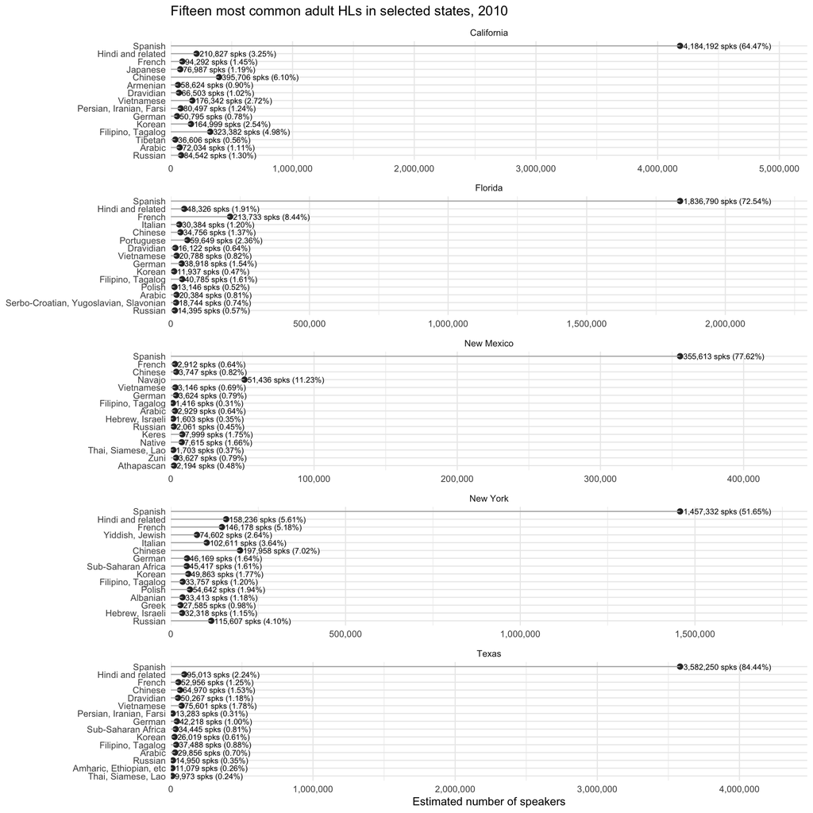

```r
selected_states <- c("California", "Texas", "New York", "Florida", "New Mexico")

fig3_data <- analytic |>
  filter(year == 2010, adult_hl, state %in% selected_states, !is.na(language)) |>
  group_by(state, language) |>
  summarise(n = weighted_n(perwt), .groups = "drop") |>
  group_by(state) |>
  mutate(prop = n / sum(n)) |>
  slice_max(n, n = 15, with_ties = FALSE) |>
  ungroup() |>
  mutate(label = paste0(fmt_n(n), " spks (", fmt_pct(prop), ")"))

ggplot(fig3_data, aes(x = n, y = fct_reorder(language, n))) +
  geom_point(size = 2.2, color = "gray20") +
  geom_segment(aes(x = 0, xend = n, yend = fct_reorder(language, n)), color = "gray70") +
  geom_text(aes(label = label), hjust = -0.04, size = 2.7) +
  facet_wrap(~ state, scales = "free", ncol = 1) +
  scale_x_continuous(labels = comma, expand = expansion(mult = c(0, 0.25))) +
  labs(
    title = "Fifteen most common adult HLs in selected states, 2010",
    x = "Estimated number of speakers",
    y = NULL
  ) +
  theme_minimal(base_size = 11)
```

# 12 Table 8: Gini Index of Adult HL Speakers by Language

The paper uses the Gini index as a measure of geographic concentration. A value near 0 means a language group is evenly distributed across geographic units; a value near 1 means the group is concentrated in a small number of units.

For this replication, the geographic unit is the state-specific `CONSPUMA`, matching the paper’s note that ConsPUMA is the sample unit. Zero-speaker ConsPUMAs are included for each language-year combination so that the Gini index captures concentration rather than only dispersion among non-zero areas.

```r
gini_years <- c(1980, 2000, 2010)

geo_units <- analytic |>
  filter(year %in% gini_years) |>
  distinct(year, state_conspuma)

language_years <- analytic |>
  filter(year %in% gini_years, adult_hl, !is.na(language)) |>
  distinct(year, language)

geo_language_counts <- analytic |>
  filter(year %in% gini_years, adult_hl, !is.na(language)) |>
  group_by(year, state_conspuma, language) |>
  summarise(n = weighted_n(perwt), .groups = "drop")

gini_table <- language_years |>
  inner_join(geo_units, by = "year") |>
  left_join(geo_language_counts, by = c("year", "state_conspuma", "language")) |>
  mutate(n = replace_na(n, 0)) |>
  group_by(language, year) |>
  summarise(gini = gini(n), .groups = "drop") |>
  pivot_wider(names_from = year, values_from = gini) |>
  mutate(`Change 1980-2010` = `2010` - `1980`) |>
  arrange(desc(`2010`))

gini_table |>
  mutate(across(c(`1980`, `2000`, `2010`, `Change 1980-2010`), ~ round(.x, 3))) |>
  kable(caption = "Replication of Table 8: Gini Index by Language")
```

Replication of Table 8: Gini Index by Language

| language | 1980 | 2000 | 2010 | Change 1980-2010 |
| --- | --- | --- | --- | --- |
| Keres | NA | 0.998 | 0.998 | NA |
| Zuni | NA | NA | 0.998 | NA |
| Aleut, Eskimo | NA | 0.997 | 0.997 | NA |
| Siouan languages | NA | 0.990 | 0.992 | NA |
| Navajo | NA | 0.989 | 0.991 | NA |
| African, n.s | 0.972 | 0.973 | 0.987 | 0.015 |
| Hawaiian | 0.984 | 0.994 | 0.985 | 0.001 |
| American Indian, n.s | NA | NA | 0.982 | NA |
| Iroquoian | NA | 0.987 | 0.981 | NA |
| Yiddish, Jewish | 0.927 | 0.951 | 0.981 | 0.054 |
| Near East Arabic dialect | 0.976 | 0.978 | 0.979 | 0.003 |
| Armenian | 0.971 | 0.963 | 0.978 | 0.007 |
| Other Persian dialects | 0.992 | 0.990 | 0.976 | -0.016 |
| Athapascan | NA | 0.993 | 0.970 | NA |
| Tibetan | 0.973 | 0.968 | 0.966 | -0.007 |
| Celtic | 0.911 | 0.941 | 0.965 | 0.054 |
| Hamitic | 0.984 | 0.984 | 0.962 | -0.022 |
| Albanian | 0.976 | 0.943 | 0.960 | -0.017 |
| Finnish | 0.930 | 0.951 | 0.959 | 0.029 |
| Other Malayan | 0.969 | 0.967 | 0.958 | -0.011 |
| Native | NA | NA | 0.957 | NA |
| Lithuanian | 0.924 | 0.935 | 0.953 | 0.029 |
| Burmese, Lisu, Lolo | 0.994 | 0.982 | 0.952 | -0.042 |
| Danish | 0.905 | 0.942 | 0.950 | 0.045 |
| Amharic, Ethiopian, etc | 0.983 | 0.955 | 0.948 | -0.035 |
| Norwegian | 0.930 | 0.924 | 0.948 | 0.018 |
| Other East/Southeast Asian | 0.977 | 0.954 | 0.948 | -0.029 |
| Slovak | 0.921 | 0.942 | 0.947 | 0.026 |
| Other or not reported | 0.700 | 0.862 | 0.943 | 0.243 |
| Micronesian, Polynesian | 0.961 | 0.946 | 0.941 | -0.020 |
| Czech | 0.905 | 0.914 | 0.939 | 0.035 |
| Other Balto-Slavic | 0.971 | 0.959 | 0.937 | -0.035 |
| Ukrainian, Ruthenian, Little Russian | 0.872 | 0.924 | 0.931 | 0.058 |
| Magyar, Hungarian | 0.855 | 0.882 | 0.930 | 0.075 |
| Swedish | 0.872 | 0.905 | 0.928 | 0.056 |
| Persian, Iranian, Farsi | 0.875 | 0.937 | 0.928 | 0.052 |
| Indonesian | 0.966 | 0.950 | 0.927 | -0.039 |
| Rumanian | 0.969 | 0.936 | 0.926 | -0.043 |
| Turkish | 0.944 | 0.933 | 0.918 | -0.026 |
| Hebrew, Israeli | 0.935 | 0.927 | 0.916 | -0.019 |
| Polish | 0.827 | 0.853 | 0.892 | 0.065 |
| Portuguese | 0.938 | 0.896 | 0.890 | -0.048 |
| Serbo-Croatian, Yugoslavian, Slavonian | 0.888 | 0.878 | 0.886 | -0.002 |
| Dutch | 0.838 | 0.842 | 0.885 | 0.047 |
| Thai, Siamese, Lao | 0.882 | 0.873 | 0.883 | 0.001 |
| Korean | 0.866 | 0.871 | 0.874 | 0.008 |
| Vietnamese | 0.884 | 0.891 | 0.874 | -0.010 |
| Japanese | 0.914 | 0.840 | 0.869 | -0.045 |
| Filipino, Tagalog | 0.913 | 0.889 | 0.864 | -0.049 |
| Sub-Saharan Africa | 0.915 | 0.886 | 0.863 | -0.052 |
| Russian | 0.910 | 0.871 | 0.853 | -0.058 |
| Dravidian | 0.935 | 0.892 | 0.852 | -0.082 |
| Greek | 0.840 | 0.848 | 0.850 | 0.010 |
| Chinese | 0.886 | 0.870 | 0.833 | -0.053 |
| Arabic | 0.845 | 0.826 | 0.827 | -0.018 |
| Hindi and related | 0.861 | 0.831 | 0.821 | -0.040 |
| Italian | 0.808 | 0.797 | 0.801 | -0.007 |
| French | 0.796 | 0.757 | 0.788 | -0.008 |
| Spanish | 0.827 | 0.772 | 0.767 | -0.060 |
| German | 0.634 | 0.617 | 0.668 | 0.035 |
| Algonquian | NA | 0.972 | NA | NA |
| American Indian (all) | 0.936 | NA | NA | NA |
| Basque | 0.986 | NA | NA | NA |
| Caucasian, Georgian, Avar | 0.994 | NA | NA | NA |
| Icelandic | 0.976 | 0.989 | NA | NA |
| Kurukh | 0.996 | NA | NA | NA |
| Muskogean | NA | 0.994 | NA | NA |
| Other Altaic | 0.984 | NA | NA | NA |
| Romany, Gypsy | 0.990 | NA | NA | NA |
| Slovene | 0.964 | NA | NA | NA |
| Uralic | 0.997 | NA | NA | NA |

# 13 Replication Notes

The code above follows the published workflow as closely as the available public-use variables allow. Important implementation choices are:

Likely sources of differences from the published article include:

- These files are reduced samples rather than the full research extracts.
- IPUMS language coding changed over time, especially for Native American language categories; some categories exist in only some years.
- The paper’s printed figures and tables may have included additional manual recoding or formatting not documented in the article.
- Age at immigration is approximated from year of immigration and census year.